# Xác định năm có dịch

## Cách 1: Dựa trên tỷ lệ ca nặng

Đối với Dengue thì chẩn đoán có 3 loại: Dengue, Dengue cảnh báo và Dengue nặng

Đối với HFMD thì chẩn đoán có 4 loại: Độ 1, Độ 2A, Độ 2B, Độ 3 và Độ 4

Do đó, **ca nặng** được sử dụng cho Dengue (Dengue nặng) và cho HFMD (Từ Độ 2B trở lên):

–> Không tin cậy để sử dụng đánh giá năm dịch.

```r
df_c1_wide <- df_sxh %>%
  select(Year, Total_Cases, Total_Sev, Pct_Sev) %>%
  left_join(
    df_tcm %>% select(Year, Total_Cases, Total_Sev, Pct_Sev),
    by = "Year", suffix = c("_SXH", "_TCM")
  ) %>% arrange(Year)

tbl_c1 <- df_c1_wide %>%
  gt() %>%
  tab_spanner(label = md("**Dengue**"), columns = ends_with("_SXH")) %>%
  tab_spanner(label = md("**THFMD**"), columns = ends_with("_TCM")) %>%
  cols_label(
    Total_Cases_SXH = "Total cases", Total_Sev_SXH = "Sev cases", Pct_Sev_SXH = "Pct (%)",
    Total_Cases_TCM = "Total cases", Total_Sev_TCM = "Sev cases", Pct_Sev_TCM = "Pct (%)"
  ) %>%
  fmt_number(columns = c(Pct_Sev_SXH, Pct_Sev_TCM), decimals = 2)

tbl_c1
```

| Year | **Dengue** Total cases | **Dengue** Sev cases | **Dengue** Pct (%) | **THFMD** Total cases | **THFMD** Sev cases | **THFMD** Pct (%) |
| --- | --- | --- | --- | --- | --- | --- |
| 2016 | 30262 | 376 | 1.24 | 5701 | 120 | 2.10 |
| 2017 | 47871 | 380 | 0.79 | 38353 | 36 | 0.09 |
| 2018 | 57852 | 223 | 0.39 | 49727 | 106 | 0.21 |
| 2019 | 91700 | 200 | 0.22 | 36328 | 77 | 0.21 |
| 2020 | 33120 | 160 | 0.48 | 21836 | 76 | 0.35 |
| 2021 | 21668 | 276 | 1.27 | 12348 | 66 | 0.53 |
| 2022 | 110792 | 2731 | 2.46 | 23134 | 51 | 0.22 |
| 2023 | 25584 | 703 | 2.75 | 53553 | 959 | 1.79 |
| 2024 | 22866 | 533 | 2.33 | 21681 | 143 | 0.66 |
| 2025 | 64328 | 2298 | 3.57 | 36789 | 124 | 0.34 |

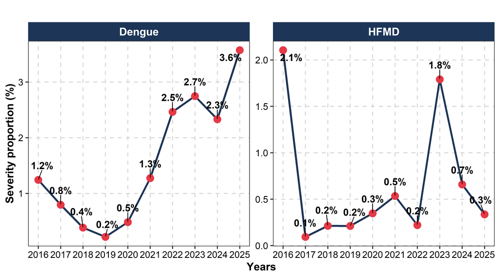

```r
plot_c1_severity <- ggplot(df_all, aes(x = Year, y = Pct_Sev)) +
  geom_line(color = "#1D3557", size = 1.2) +
  geom_point(color = "#E63946", size = 4) +
  geom_text_repel(aes(label = paste0(round(Pct_Sev, 1), "%")), size = 4.5, fontface = "bold", vjust = -1.5) +
  facet_wrap(~ Disease, scales = "free_y") +
  scale_x_continuous(breaks = unique(df_all$Year)) +
  labs(title = "", x = "Years", y = "Severity proportion (%)") +
  theme_hcdc_report()

plot_c1_severity
```

## Cách 2: Xem outlier của số ca, đỉnh dịch và tốc độ gia tăng của số ca

Do không thể dùng **số ca nặng** để đánh giá năm dịch, chúng ta phải dựa vào số ca mắc ghi nhận được. Tuy nhiên, ngoài việc dựa vào Total cases của từng năm, chúng ta có thể dựa vào Peak cases và Max Acel (Số ca tăng qua mỗi tuần) của từng năm.

Đối với cách này, outliers được xác định nếu vượt quá ngưỡng $Upper fence = Q3 + 1.5*(IQR)$ theo từng features (Total cases, Peak cases, Max Acel). Vì Dengue và HFMD là 2 bệnh lưu hành lâu năm tại TPHCM, do đó đối với Total cases không thể xác định được năm nào là outliers, vì có đến 3-4 năm trong 10 năm dữ liệu này có Total cases đều cao, dẫn đến Q3 của toàn bộ dữ liệu rất cao.

Giả thuyết của chúng em kì vọng rằng năm dịch là năm bất thường về cả 3 features. Do đó, việc dùng outliers để xác định năm dịch có thể không khả thi, vì cách này phải có mẫu lớn hơn để thực hiện.

```r
df_c2 <- df_all %>%
  group_by(Disease) %>%
  mutate(
    q3_cases = quantile(Total_Cases, 0.75, na.rm = TRUE),
    out_cases = q3_cases + 1.5 * IQR(Total_Cases, na.rm = TRUE),

    q3_peak = quantile(Peak_Cases, 0.75, na.rm = TRUE),
    out_peak = q3_peak + 1.5 * IQR(Peak_Cases, na.rm = TRUE),

    q3_accel = quantile(Max_Accel, 0.75, na.rm = TRUE),
    out_accel = q3_accel + 1.5 * IQR(Max_Accel, na.rm = TRUE)
  ) %>%
  ungroup() %>%
  mutate(
    Outlier_Cases = ifelse(Total_Cases > out_cases, "Outlier", "Normal"),
    Outlier_Peak = ifelse(Peak_Cases > out_peak, "Outlier", "Normal"),
    Outlier_Accel = ifelse(Max_Accel > out_accel, "Outlier", "Normal")
  )

df_c2_wide <- df_c2 %>% filter(Disease == "Dengue") %>%
  select(Year, Total_Cases, Outlier_Cases, Peak_Cases, Outlier_Peak, Max_Accel, Outlier_Accel) %>%
  left_join(
    df_c2 %>% filter(Disease == "HFMD") %>%
    select(Year, Total_Cases, Outlier_Cases, Peak_Cases, Outlier_Peak, Max_Accel, Outlier_Accel),
    by = "Year", suffix = c("_SXH", "_TCM")
  ) %>% arrange(Year)

tbl_c2 <- df_c2_wide %>%
  gt() %>%
  tab_spanner(label = md("**Dengue**"), columns = ends_with("_SXH")) %>%
  tab_spanner(label = md("**HFMD**"), columns = ends_with("_TCM")) %>%
  cols_label(
    Total_Cases_SXH = "Total", Outlier_Cases_SXH = "Status",
    Peak_Cases_SXH = "Peak", Outlier_Peak_SXH = "Status",
    Max_Accel_SXH = "Max Accel", Outlier_Accel_SXH = "Status",
    Total_Cases_TCM = "Total", Outlier_Cases_TCM = "Status",
    Peak_Cases_TCM = "Peak", Outlier_Peak_TCM = "Status",
    Max_Accel_TCM = "Max Accel", Outlier_Accel_TCM = "Status"
  )

tbl_c2
```

| Year | **Dengue** Total | **Dengue** Status | **Dengue** Peak | **Dengue** Status | **Dengue** Max Accel | **Dengue** Status | **HFMD** Total | **HFMD** Status | **HFMD** Peak | **HFMD** Status | **HFMD** Max Accel | **HFMD** Status |
| --- | --- | --- | --- | --- | --- | --- | --- | --- | --- | --- | --- | --- |
| 2016 | 30262 | Normal | 1261 | Normal | 832 | Normal | 5701 | Normal | 205 | Normal | 79 | Normal |
| 2017 | 47871 | Normal | 1598 | Normal | 844 | Normal | 38353 | Normal | 1920 | Normal | 435 | Normal |
| 2018 | 57852 | Normal | 2549 | Normal | 1511 | Normal | 49727 | Normal | 4418 | Outlier | 933 | Normal |
| 2019 | 91700 | Normal | 3249 | Normal | 2219 | Outlier | 36328 | Normal | 2435 | Normal | 598 | Normal |
| 2020 | 33120 | Normal | 1223 | Normal | 1141 | Normal | 21836 | Normal | 1371 | Normal | 436 | Normal |
| 2021 | 21668 | Normal | 1067 | Normal | 816 | Normal | 12348 | Normal | 1493 | Normal | 538 | Normal |
| 2022 | 110792 | Normal | 4844 | Normal | 814 | Normal | 23134 | Normal | 1338 | Normal | 375 | Normal |
| 2023 | 25584 | Normal | 1013 | Normal | 1013 | Normal | 53553 | Normal | 3339 | Normal | 733 | Normal |
| 2024 | 22866 | Normal | 1043 | Normal | 812 | Normal | 21681 | Normal | 825 | Normal | 704 | Normal |
| 2025 | 64328 | Normal | 2725 | Normal | 712 | Normal | 36789 | Normal | 1653 | Normal | 303 | Normal |

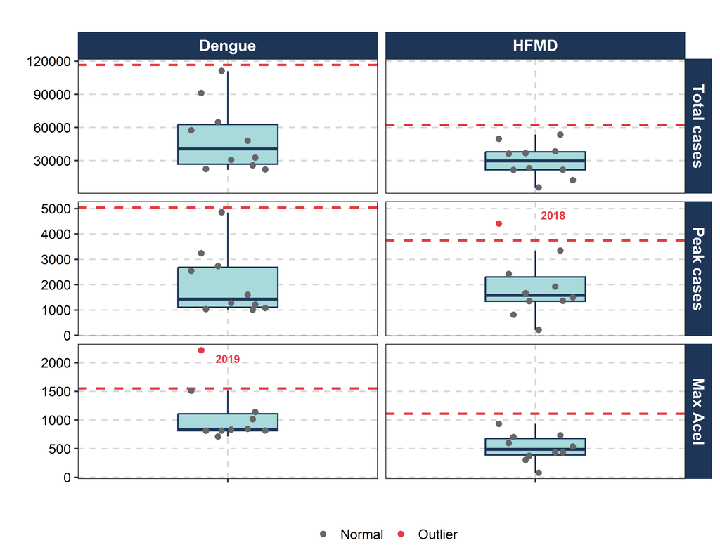

```r
df_c2_long <- df_c2 %>%
  select(Disease, Year, Total_Cases, Peak_Cases, Max_Accel,
         out_cases, out_peak, out_accel,
         Outlier_Cases, Outlier_Peak, Outlier_Accel) %>%
  pivot_longer(
    cols = c(Total_Cases, Peak_Cases, Max_Accel),
    names_to = "Metric",
    values_to = "Value"
  ) %>%
  mutate(
    Threshold = case_when(
      Metric == "Total_Cases" ~ out_cases,
      Metric == "Peak_Cases" ~ out_peak,
      Metric == "Max_Accel" ~ out_accel
    ),
    Outlier_Status = case_when(
      Metric == "Total_Cases" ~ Outlier_Cases,
      Metric == "Peak_Cases" ~ Outlier_Peak,
      Metric == "Max_Accel" ~ Outlier_Accel
    ),
    Metric = case_when(
      Metric == "Total_Cases" ~ "Total cases",
      Metric == "Peak_Cases" ~ "Peak cases",
      Metric == "Max_Accel" ~ "Max Acel"
    )
  )

df_c2_long$Metric <- factor(df_c2_long$Metric, levels = c("Total cases", "Peak cases", "Max Acel"))

plot_c2_boxplots <- ggplot(df_c2_long, aes(x = "", y = Value)) +
  geom_boxplot(fill = "#A8DADC", color = "#1D3557", width = 0.4, outlier.shape = NA) +
  geom_hline(aes(yintercept = Threshold), color = "#E63946", linetype = "dashed", size = 1) +
  geom_jitter(aes(color = Outlier_Status), width = 0.15, size = 2) +
  geom_text_repel(
    data = filter(df_c2_long, Outlier_Status == "Outlier"),
    aes(label = Year, color = Outlier_Status),
    size = 3.5, fontface = "bold", show.legend = FALSE
  ) +

  facet_grid(Metric ~ Disease, scales = "free") +
  scale_color_manual(values = c("Outlier" = "#E63946", "Normal" = "gray40"), limits = c("Normal", "Outlier")) +
  labs(title = "", x = "", y = "", color = "") +
  theme_hcdc_report() +
  theme(
    axis.text.x = element_blank(),
    legend.position = "bottom"
  )

plot_c2_boxplots
```

## Cách 3: K-means Clustering

Thay vì xem riêng lẻ từng features, thuật toán K-Means Clustering sẽ xem tác động của cả 3 features trên 1 chiều không gian đa chiều.

Đầu tiên thuật toán sẽ tạo ra 2 tâm (A và B). với giá trị ngẫu nhiên trong phạm vi của dữ liệu. Tiếp theo sẽ tính khoảng cách từ từng điểm dữ liệu đến mỗi tâm, khoảng cách đến tâm nào ngắn hơn sẽ gom về cụm của tâm đó, nghĩa là sẽ có 2 cụm A và B. Sau đó, sẽ cập nhật lại tâm mới bằng cách sử dụng trung bình cộng của tất cả điểm dữ liệu thuộc cụm đó. Sẽ lặp lại các bước trên đến khi 2 tâm không còn thay đổi nữa sẽ chốt 2 cụm A và B.

Trong bài toán này, dữ liệu từ 2016 - 2025 (10 năm) sẽ được chia thành 2 cụm (năm dịch và năm bình thường) dựa trên cả 3 features (Total cases, Peak cases, Max Acel)

```r
run_kmeans <- function(df) {
  df_scaled <- scale(df %>% select(Total_Cases, Peak_Cases, Max_Accel))
  set.seed(42)
  km <- kmeans(df_scaled, centers = 2, nstart = 25)
  df$Cluster <- km$cluster
  mean_c <- df %>% group_by(Cluster) %>% summarise(m = mean(Total_Cases))
  epi_id <- mean_c$Cluster[which.max(mean_c$m)]
  df %>% mutate(Status = ifelse(Cluster == epi_id, "Epidemic years", "Endemic years"))
}

df_c3 <- bind_rows(run_kmeans(df_sxh), run_kmeans(df_tcm))

df_c3_wide <- df_c3 %>% filter(Disease == "Dengue") %>%
  select(Year, Status, Total_Cases, Peak_Cases, Max_Accel) %>%
  left_join(
    df_c3 %>% filter(Disease == "HFMD") %>%
    select(Year, Status, Total_Cases, Peak_Cases, Max_Accel),
    by = "Year", suffix = c("_SXH", "_TCM")
  ) %>% arrange(Year)

tbl_c3 <- df_c3_wide %>%
  gt() %>%
  tab_spanner(label = md("**Dengue**"), columns = ends_with("_SXH")) %>%
  tab_spanner(label = md("**HFMD**"), columns = ends_with("_TCM")) %>%
  cols_label(
    Status_SXH = "Status", Total_Cases_SXH = "Total cases", Peak_Cases_SXH = "Peak cases", Max_Accel_SXH = "Max Accel",
    Status_TCM = "Status", Total_Cases_TCM = "Total cases", Peak_Cases_TCM = "Peak cases", Max_Accel_TCM = "Max Accel"
  )

tbl_c3
```

| Year | **Dengue** Status | **Dengue** Total cases | **Dengue** Peak cases | **Dengue** Max Accel | **HFMD** Status | **HFMD** Total cases | **HFMD** Peak cases | **HFMD** Max Accel |
| --- | --- | --- | --- | --- | --- | --- | --- | --- |
| 2016 | Endemic years | 30262 | 1261 | 832 | Endemic years | 5701 | 205 | 79 |
| 2017 | Endemic years | 47871 | 1598 | 844 | Endemic years | 38353 | 1920 | 435 |
| 2018 | Epidemic years | 57852 | 2549 | 1511 | Epidemic years | 49727 | 4418 | 933 |
| 2019 | Epidemic years | 91700 | 3249 | 2219 | Endemic years | 36328 | 2435 | 598 |
| 2020 | Endemic years | 33120 | 1223 | 1141 | Endemic years | 21836 | 1371 | 436 |
| 2021 | Endemic years | 21668 | 1067 | 816 | Endemic years | 12348 | 1493 | 538 |
| 2022 | Epidemic years | 110792 | 4844 | 814 | Endemic years | 23134 | 1338 | 375 |
| 2023 | Endemic years | 25584 | 1013 | 1013 | Epidemic years | 53553 | 3339 | 733 |
| 2024 | Endemic years | 22866 | 1043 | 812 | Endemic years | 21681 | 825 | 704 |
| 2025 | Endemic years | 64328 | 2725 | 712 | Endemic years | 36789 | 1653 | 303 |

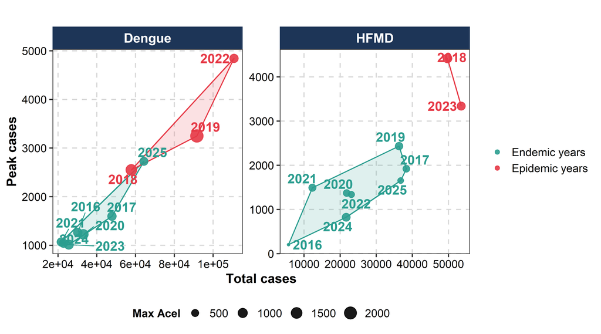

```r
# Convex Hull data
hull_c3 <- df_c3 %>% group_by(Disease, Status) %>% slice(chull(Total_Cases, Peak_Cases))

plot_c3_kmeans <- ggplot(df_c3, aes(x = Total_Cases, y = Peak_Cases)) +
  geom_polygon(data = hull_c3, aes(fill = Status, color = Status), alpha = 0.15, show.legend = FALSE) +
  geom_point(aes(color = Status, size = Max_Accel), alpha = 0.9) +
  geom_text_repel(aes(label = Year, color = Status), size = 5, fontface = "bold", show.legend = FALSE) +
  facet_wrap(~ Disease, scales = "free") +
  scale_color_manual(values = c("Epidemic years" = "#E63946", "Endemic years" = "#2A9D8F")) +
  scale_fill_manual(values = c("Epidemic years" = "#E63946", "Endemic years" = "#2A9D8F")) +
  labs(title = "", x = "Total cases", y = "Peak cases", size = "Max Acel", color = "") +
  theme_hcdc_report() +
  theme(legend.position = "right") +

  guides(
    size = guide_legend(position = "bottom"),
    color = guide_legend(position = "right")
  )

plot_c3_kmeans
```

## Cách 4: Isolate Forest

Khác với thuật toán K-Means Clustering tìm cách gom nhóm các năm có tính chất giống nhau dựa trên khoảng cách, thuật toán Isolation Forest lại tập trung đi tìm sự dị biệt (anomalies) bằng cách chia cắt không gian dữ liệu đa chiều.

Đầu tiên, thuật toán sẽ xây dựng một Decision tree bằng cách chọn ngẫu nhiên 1 trong 3 features và tạo ra một nhát cắt ngẫu nhiên để chia đôi dữ liệu (Yes/No). Ở những nhát cắt tiếp theo, thuật toán vẫn tiếp tục chọn ngẫu nhiên 1 trong cả 3 features (có thể lặp lại feature đã cắt trước đó). Quá trình chẻ nhánh này diễn ra liên tục cho đến khi mỗi điểm dữ liệu (từng năm) đều bị cô lập vào một ô riêng biệt. Vì các năm có tính chất bất thường nên sẽ bị cô lập rất nhanh chỉ sau một vài nhát cắt. Ngược lại, các năm bình thường có tính chất gần như nhau nên phải tốn rất nhiều nhát cắt mới chia tách được. Thuật toán sẽ lặp lại quá trình này trên hàng trăm cây khác nhau, lấy trung bình độ sâu của số nhát cắt và quy đổi thành điểm dị biệt (Anomaly Score) từ 0 đến 1.

Trong bài toán này, dữ liệu 10 năm (2016 - 2025) cũng được đánh giá mức độ dị biệt dựa trên sự kết hợp của 3 features (Total cases, Peak cases, Max Acel). Năm nào có Anomaly Score vượt ngưỡng 0.5 sẽ được cảnh báo mức độ dị thường.

```r
run_iso <- function(df) {
  model <- isolation.forest(df %>% select(Total_Cases, Peak_Cases, Max_Accel), ntrees = 100, seed = 123)
  df$Anomaly_Score <- predict(model, df %>% select(Total_Cases, Peak_Cases, Max_Accel))
  df$Iso_Status <- ifelse(df$Anomaly_Score >= 0.5, "Epidemic years", "Endemic years")
  list(data = df, model = model)
}

iso_sxh <- run_iso(df_sxh)
iso_tcm <- run_iso(df_tcm)
df_c4 <- bind_rows(iso_sxh$data, iso_tcm$data)

df_c4_wide <- df_c4 %>% filter(Disease == "Dengue") %>%
  select(Year, Anomaly_Score, Iso_Status) %>%
  left_join(
    df_c4 %>% filter(Disease == "HFMD") %>%
    select(Year, Anomaly_Score, Iso_Status),
    by = "Year", suffix = c("_SXH", "_TCM")
  ) %>% arrange(Year)

tbl_c4 <- df_c4_wide %>%
  gt() %>%
  tab_spanner(label = md("**Dengue**"), columns = ends_with("_SXH")) %>%
  tab_spanner(label = md("**HFMD**"), columns = ends_with("_TCM")) %>%
  cols_label(
    Anomaly_Score_SXH = "Score", Iso_Status_SXH = "Status",
    Anomaly_Score_TCM = "Score", Iso_Status_TCM = "Status"
  ) %>%
  fmt_number(columns = starts_with("Anomaly_Score"), decimals = 3)

tbl_c4
```

| Year | **Dengue** Score | **Dengue** Status | **HFMD** Score | **HFMD** Status |
| --- | --- | --- | --- | --- |
| 2016 | 0.410 | Endemic years | 0.639 | Epidemic years |
| 2017 | 0.458 | Endemic years | 0.428 | Endemic years |
| 2018 | 0.527 | Epidemic years | 0.640 | Epidemic years |
| 2019 | 0.620 | Epidemic years | 0.449 | Endemic years |
| 2020 | 0.461 | Endemic years | 0.391 | Endemic years |
| 2021 | 0.411 | Endemic years | 0.460 | Endemic years |
| 2022 | 0.654 | Epidemic years | 0.420 | Endemic years |
| 2023 | 0.454 | Endemic years | 0.539 | Epidemic years |
| 2024 | 0.406 | Endemic years | 0.463 | Endemic years |
| 2025 | 0.506 | Epidemic years | 0.470 | Endemic years |

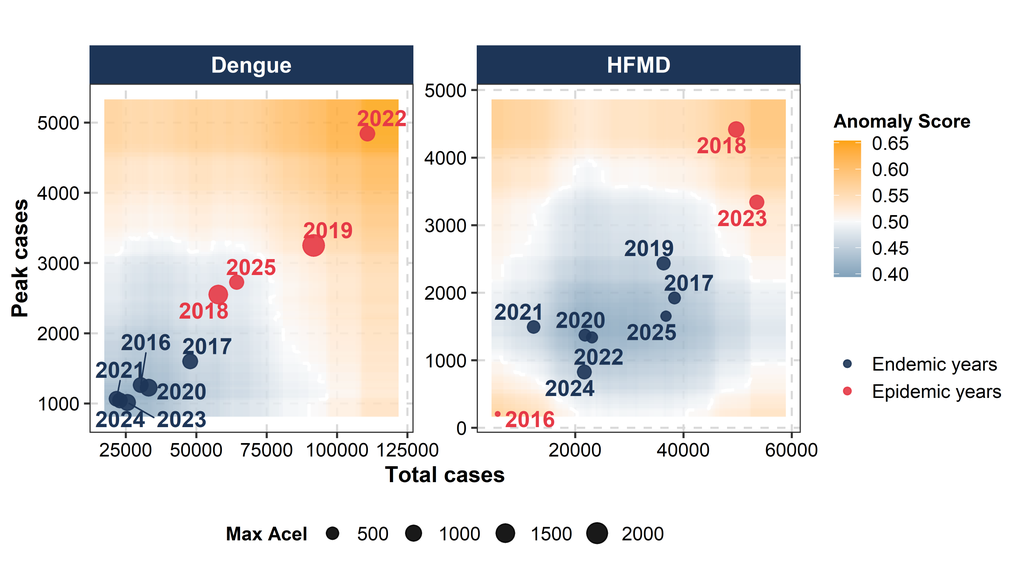

```r
create_grid <- function(df, model, dis_name) {
  g_x <- seq(min(df$Total_Cases)*0.8, max(df$Total_Cases)*1.1, length.out=150)
  g_y <- seq(min(df$Peak_Cases)*0.8, max(df$Peak_Cases)*1.1, length.out=150)
  grid <- expand.grid(Total_Cases = g_x, Peak_Cases = g_y)
  grid$Max_Accel <- median(df$Max_Accel)
  grid$Grid_Score <- predict(model, grid)
  grid$Disease <- dis_name
  return(grid)
}

grid_all <- bind_rows(
  create_grid(iso_sxh$data, iso_sxh$model, "Dengue"),
  create_grid(iso_tcm$data, iso_tcm$model, "HFMD")
)

plot_c4_contour <- ggplot() +
  geom_raster(data = grid_all, aes(x = Total_Cases, y = Peak_Cases, fill = Grid_Score), alpha = 0.85) +
  geom_contour(data = grid_all, aes(x = Total_Cases, y = Peak_Cases, z = Grid_Score), breaks = c(0.5), color = "white", linetype = "dashed", size = 1) +
  scale_fill_gradient2(low = "#457B9D", mid = "#f8f9fa", high = "#fca311", midpoint = 0.5, name = "Anomaly Score") +
  geom_point(data = df_c4, aes(x = Total_Cases, y = Peak_Cases, size = Max_Accel, color = Iso_Status), shape = 19, alpha = 0.9) +
  geom_text_repel(data = df_c4, aes(x = Total_Cases, y = Peak_Cases, label = Year, color = Iso_Status), size = 5, fontface = "bold", show.legend = FALSE) +
  scale_color_manual(values = c("Epidemic years" = "#E63946", "Endemic years" = "#1D3557")) +
  facet_wrap(~ Disease, scales = "free") +
  labs(title = "", x = "Total cases", y = "Peak cases", size = "Max Acel", color = "") +
  theme_hcdc_report() +
  theme(legend.position = "right") +

  guides(
    size = guide_legend(position = "bottom"),
    color = guide_legend(position = "right"),
    fill = guide_colorbar(position = "right")
  )

plot_c4_contour
```

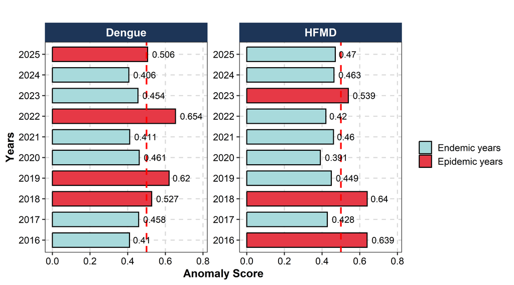

```r
plot_c4_bar <- ggplot(df_c4, aes(x = Anomaly_Score, y = as.factor(Year), fill = Iso_Status)) +
  geom_col(color = "black", width = 0.7) +
  geom_vline(xintercept = 0.5, linetype = "dashed", color = "red", linewidth = 1) +
  geom_text(aes(label = round(Anomaly_Score, 3)), hjust = -0.2, size = 4, color = "black") +
  scale_fill_manual(values = c("Epidemic years" = "#E63946", "Endemic years" = "#A8DADC")) +
  scale_x_continuous(limits = c(0, max(df_c4$Anomaly_Score) * 1.2)) +
  facet_wrap(~ Disease, scales = "free_y") +
  labs(title = "", x = "Anomaly Score", y = "Years", fill = "") +
  theme_hcdc_report() +
  theme(legend.position = "right")

plot_c4_bar
```